**CSE2215** - Computer Graphics

Elmar Eisemann, Ricardo Marroqium, Mathijs Molenaar

# Linear Algebra Exercises

To get you started with graphical applications, this week you will work on three short visual exercises (**non-graded**). From now on, we will use an external library called **glm**. Hence, these exercises will also help you to get acquainted with the setup for the next practicals and make sure that everything is running smoothly in your computer.

## OpenGL Math Library (glm)

Unlike the previous week, you do not have to implement the linear algebra constructs yourself. Instead we will use the [glm](https://glm.g-truc.net/0.9.9/index.html) library. This library has 2D, 3D and 4D vectors and matrices, as well as many operations that can be applied to these types. For these exercises you will only need to work with 3D vectors, but more explanation on using glm with matrices and transformations will be given for the next practical.

We can create a 2D/3D/4D `glm` vector in various ways:

```cpp
glm::vec3 myFirstVec3 { 1, 2, 3 }; // Creates a vector (1, 2, 3)
glm::vec3 singleValueVec3 { 5 }; // Creates a vector (5, 5, 5)

glm::vec2 multiValueVec2 { 1, 2 }; // Creates a vector (1, 2)
glm::vec3 multiValueVec3 { myFirstVec2, 3 }; // Creates a vector (1, 2, 3)
glm::vec4 multiValueVec4 { multiValueVec3, 4 }; // Creates a vector (1, 2, 3, 4)
```

Unlike our simple vector class that we implemented in the first assignment, glm supports operator overloading. Operator overloading is a powerfull feature in `c++` which allows us (or in this case, `glm`) to define the behavior of the `+`, `-`, `*` and `/` operands for a custom class. In practice, this means that math heavy code is greatly simplified.

```cpp
glm::vec3 a { 2, 5, 3 };
glm::vec3 b { 9, -3, -1 };
glm::vec3 c = a + b; // (11, 2, 2)
```

Additionally, glm provides some helper functions for vector operations.

```cpp
// consider two glm::vec3 a and b
float dot = glm::dot(a, b); // dot product returns a scalar value
glm::vec3 cross = glm::cross(a, b); // cross product returns another vector
a = glm::normalize(a); // normalize vector a
```

You can find the full `glm` manual [here](https://github.com/g-truc/glm/blob/0.9.9.2/doc/manual.pdf).

## Linear Algebra exercises

There are three exercises. You can switch between them using the GUI. Each one has visual feedback of your answer. To check if your code is correct, we also provide two options:

1. generate random scenarios to test your algorithm where you can visually check your results.
2. seriers of test cases with the correct answer. Pressing the button “Check Solution” retrieves one of these test cases, compares the result with your solution, and outputs wether is matches or not (correct/wrong).

You only need to work with the file `src/la.cpp`, but feel free to modify the other files to try things out. These are non-graded exercises so it is also a good time to experiment a bit. Getting acquainted with the rest of the code will also help with the upcoming practicals and final project.

## 1. Point-Plane side

Consider a plane with a normal, and the front of the plane as the side the normal points towards. Given a 3D point, it may lie on the front or back side of the plane, or on the plane. In this exercise you will be given a plane and a point and should decide on which side of the plane the point is.

Here is an explanation of how you can compute the side. Let’s consider that the plane is defined by a point **p<sub>0</sub>** on the plane and its normal vector **n**. Given a 3D point **pt**, as illustrated below.

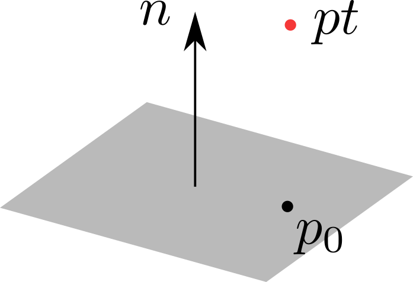

Plane and 3D point (red)

Point **pt** it will be in front of the plane if a vector from **p<sub>0</sub>** to **pt** makes an angle of 90 degrees or less with the plane normal **n**. Hint: use the dot product to compute angles between vectors.

For this exercise, If the point lies on the plane consider it to be on the front side.

The plane is represented by the following structure:

```cpp
struct Plane {
    glm::vec3 p; // a point on the plane
    glm::vec3 n; // plane's normal direction
};
```

You should complete the code in the method `isInFront` in the `src/la.cpp` file. You receive the plane and the point, and should return *true* if the point is in front or on the plane, or *false* otherwise.

You can generate a new random point or new random plane by pressing the respective buttons in the GUI. As a visual feedback, if your answer is “true” (point is in the front side) the plane will be coloured green, otherwise it will be coloured red. The 3D point is represented by a yellow sphere.

You also have the option to press “Check Solution”, in this case your answer will be compared to a pre-computed case with solution.

## 2. Triangle normal vector

In the second exercise you are asked to compute the normal of a triangle.

Given the three vertices of a triangle **v<sub>0</sub>**, **v<sub>1</sub>** and **v<sub>2</sub>**, you can find the normal vector by computing a vector that is perpendicular to two of the triangle’s edges. Hint: use the cross product to compute perpendicular vectors.

Consider that the vertices are in counter-clockwise order. The left figure below illustrates the orientation, in this case the triangle normal would be pointing towards you (outside the screen). On the right is a perspective view of the triangle.

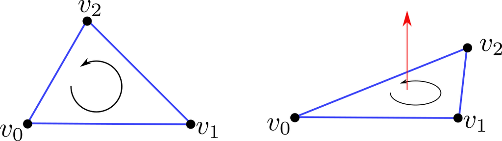

Triangle orientation and normal

A triangle is represented by the following structure:

```cpp
struct Triangle {
    glm::vec3 v0;
    glm::vec3 v1;
    glm::vec3 v2;
    glm::vec3 n;
};
```

You should complete the code in the method `computeNormal` in the `src/la.cpp` file. You receive the triangle and should return the normal vector. The normal vector should be normalized before returning it. Do not write directly to the triangle structure, the normal will then be automatically attributed to the triangle and drawn on the screen.

Again, you can generate a new random triangle or test against a pre-computed solution using the respective buttons in the GUI.

## 3. Front/Back facing triangles

Finally, given a camera position and a triangle, your task is to check if the triangle is front or back facing.

A triangle is front-facing, if its front face (side of the normal) is visible from the camera. Otherwise it is back-facing. You can check if the triangle is front facing using a similar strategy as exercise one, but now consider that your 3D point is the camera position **C** as illustrated below. The blue triangle is front facing while the red is back facing.

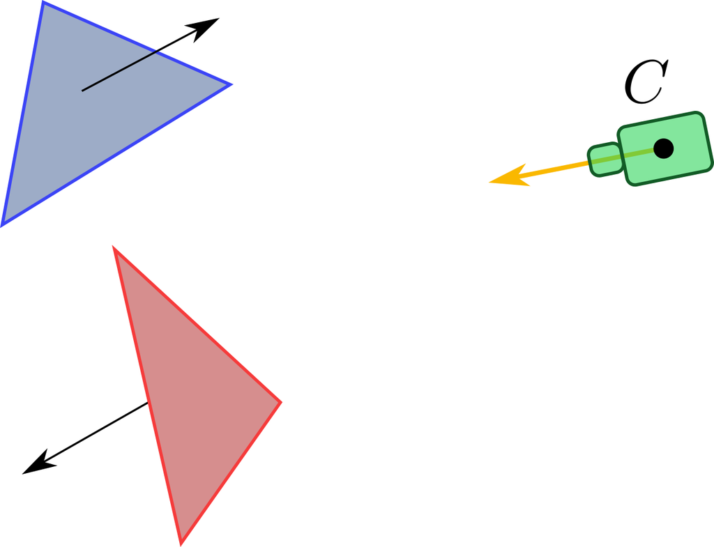

Front/Back facing triangles

You should complete the second assignment before this one as the `computeNormal` will be called internally. You should complete the code in the method ‘isFrontFacing’ in the `src/la.cpp` file. You receive the triangle and the camera position and should return *true* if the triangle is front-facing, *false* otherwise.

As a visual feedback, the normal with be shaded in green if you return *true* and in red otherwise. Note than when using the “Check solution” option the feedback (correct/wrong) is only valid until you move the camera around, as the triangle may change state from front to back facing, or vice-versa.

## Submission

Even though we strongly recommend you to do the exercises, you don’t need to hand in this assignment. Nevertheless, please note that after the assigned deadline we will give priority to answering questions related to other practicals or lecture content.